# Improving customer retention in financial services using kinship network information - ScienceDirect

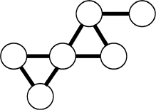

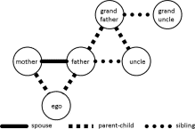

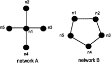

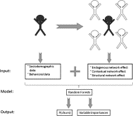

## Tables (4)

1. Table 1
2. Table 2
3. Table 3
4. Table 4

## [Expert Systems with Applications](https://www.sciencedirect.com/science/journal/09574174)

[Volume 39, Issue 13](https://www.sciencedirect.com/science/journal/09574174/39/13), 1 October 2012, Pages 11435-11442

# Improving customer retention in financial services using kinship network information

[Dries F.Benoit](https://www.sciencedirect.com/science/article/pii/S0957417412006136?via%3Dihub#!)[DirkVan den Poel](https://www.sciencedirect.com/science/article/pii/S0957417412006136?via%3Dihub#!)

https://doi.org/10.1016/j.eswa.2012.04.016[Get rights and content](https://s100.copyright.com/AppDispatchServlet?publisherName=ELS&contentID=S0957417412006136&orderBeanReset=true)

## Abstract

This study investigates the advantage of social network mining in a customer retention context. A company that is able to identify likely churners in an early stage can take appropriate steps to prevent these potential churners from actually churning and subsequently increase profit. Academics and practitioners are constantly trying to optimize their predictive-analytics models by searching for better predictors. The aim of this study is to investigate if, in addition to the conventional sets of variables (socio-demographics, purchase history, etc.), kinship network based variables improve the predictive power of customer retention models. Results show that the predictive power of the churn model can indeed be improved by adding the social network (SNA-) based variables. Including network structure measures (i.e. degree, betweenness centrality and density) increase predictive accuracy, but contextual network based variables turn out to have the highest impact on discriminating churners from non-churners. For the majority of the latter type of network variables, the importance in the model is even higher than the individual level counterpart variable.

### Highlights

► We model churn/retention behavior in financial services. ► We examine the improvement of predictions when taking customer networks into account. ► The methodology is based on the egocentric network approach. ► Inclusion of kinship-based networks considerably increases predictive accuracy. ► Network-based predictors are often better predictors than the individual based variables.

## Keywords

Network based marketing

CRM

Predictive analytics

Social network analysis (SNA)

Kinship network

Financial services

Random forests

## 1. Introduction

### 1.1. Customer Relationship Management (CRM)

In the past, companies had close relationships with their customers. They knew each customer individually and offered them personal customized service. As a result, they earned loyalty and a large share of their customers’ business. Over the years, through increased competition and mass marketing, customers interchanged personalized service for anonymity, reduced variety and lower prices (Peppard, 2000).

The current business environment is characterized by intense competition and saturated markets. Mutanen, Ahola, & Nousiainen (2006) remarks that the mass marketing approach, where each customer gets the same treatment of the company, cannot succeed in the diversity of consumer business today. Therefore, companies are practicing an approach to marketing that uses continuously refined information about current and potential customers to anticipate and respond to their needs. This marketing strategy is called Customer Relationship Management (CRM) (Peppard, 2000).

CRM is about structuring and managing the relationships with customers (Kim, Suh, & Hwang, 2003). CRM covers all the processes related to customer acquisition, customer cultivation, customer retention and the reactivation of defected customers. This study can be situated in the customer retention domain. The goal is to identify the customers with a high churn probability in order to target them with appropriate actions and consequently try to keep them within the company. These actions may include targeting these customers with appropriate “next-product-to-buy” (NPTB) as shown in Prinzie and Van den Poel (2006) for financial services.

### 1.2. Customer attrition in financial services

Personal retail banking is characterized by customers who typically spread their assets over only one or two companies and stay with a company for long periods of time (Mutanen et al., 2006). From the point of view of the financial services company, this produces a stable environment for CRM. It is argued that these companies need to operate on a long-term “cradle-to-grave” customer management strategy (Li, Sun, & Wilcox, 2005). This means that they recognize that young customers are often unprofitable in their earlier years, but become profitable at a later stage. The longer customers stay with the bank, the more they become tied to such an extent that the perceived cost of defection outweighs the benefits of shifting their banking business to another provider.

Although the process of attracting new customers is important, most financial services companies make customer retention a top priority for several reasons: in general, the longer a customer stays with a bank, the more that customer is worth (Benoit & Van den Poel, 2009). Long-term customers buy more, take less of a company’s time, are less sensitive to price differences, and bring in new customers (Ganesh et al., 2000, Reichheld, 1996). Long-term customers become less costly to serve because of the banks’ greater knowledge of the existing customer base and reduced servicing costs (Ganesh et al., 2000). In addition, the cost of winning a new customer is about five times greater than the cost of keeping an existing one (Colgate & Danaher, 2000)*.* A study by Reichheld and Sasser (1990) showed that reducing defections by just 5% can generate 85% more profits for a bank. The latter findings corroborate the results of a study of Van den Poel and Larivière (2004), which illustrated how increasing retention by just 1% resulted in substantial profit gains.

### 1.3. Network based marketing

A limitation of traditional direct marketing is that it assumes that customers act independently. In reality, a customer’s decision to buy a product is strongly influenced by his or her friends, family, business partners, etc. (Domingos & Richardson, 2001). Ignoring these network effects when deciding which customers to market to can lead to suboptimal decisions. For example, an unprofitable customer may be worth marketing to when this customer is likely to influence a lot of peers. In contrast to traditional direct marketing, network based marketing recognizes that links between consumers exist. As a result of the availability of gigantic databases of customer information today, companies now are able to target their customers taking into account their interrelatedness. Traditional marketing research does not reveal these social connections between consumers and thus cannot take advantage of links between customers.

Network based marketing assumes some kind of interdependency among customer preferences (e.g. purchase patterns, shopping habits, …). These interdependencies are measured through implicit links (e.g. matching on demographic attributes, geographic links, etc.), or through explicit links (e.g. communications between actors, family ties, etc.) (Hill, Provost, & Volinsky, 2006).

Although network based marketing offers clear advantages over direct marketing, the use of social network information in prediction modeling is a very recent phenomenon (e.g. Hill et al., 2006, Manchanda et al., 2008, Subelj et al., 2011). This study contributes to the literature by investigating if social network information can improve the accuracy of churn detection. Moreover, this is, to the best of our knowledge, the first study that investigates different types of network effects in the same research setting.

## 2. Methodology

### 2.1. Social networks

A crucial insight in network analysis is that actors and their actions are viewed as interdependent rather than as independent and autonomous units (Wasserman & Faust, 1994). Typically, a cross-sectional CRM dataset contains a single row for every customer and columns for the information on that customer, where we assume that all rows are independent of each other. However, the information embedded in social networks is not of this standard form where attributes can easily be linked to individuals. To make this clear, consider the simple graphical representation of a kinship network in Fig. 1.

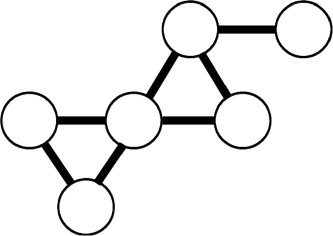

1. [Download : Download full-size image](https://ars.els-cdn.com/content/image/1-s2.0-S0957417412006136-gr1.jpg)

Fig. 1. Simple network graph

This way of representing a network is called a graph. Several dots (or ‘*nodes*’) can be seen, which correspond to the individuals or any other unit of analysis. Some nodes are linked to other nodes by lines (or ‘*ties*’). Two nodes sharing a link are ‘*adjacent*’ nodes. Together, all ties and nodes form a graph.

Nowadays we are facing a new trend in network research that is largely driven by the availability of powerful computers and the fast growing number of relational databases available to researchers (Chen, Yan, Zhu, Han, & Yu, 2009). The last couple of years, the focus is shifting away from the analysis of small-scale networks and the properties of individual ties towards large-scale statistical properties of networks (Newman, 2003). Previous studies used to look at small networks of only ten to several hundreds of nodes. However, in recent studies, it is not unusual to see networks with millions of nodes (e.g. Hill et al., 2006). Due to the dimensions of these new datasets, some specific approaches have emerged.

The data warehouse of the anonymous financial services company used for this study contains information on three categories of kinship links, i.e. parent–child relations, sibling relations and finally spouse relations. Using this information on the ties, the kinship networks of the customers were constructed. More specific, we built the networks by means of the egocentric network approach (e.g. Bar-Yossef, Guy, Lempel, Maarek, & Soroka, 2008). This means that a given customer or ‘*ego*’ is focused on and then all other customers with whom the ‘*ego*’ shares a kinship link (the ‘*alters*’) are identified (see Fig. 2). The network for this given ego is now defined. Next, we zoom in on another customer (who now becomes ‘*ego*’) and construct his/her network. This process continues until all customers’ egocentric networks are identified.

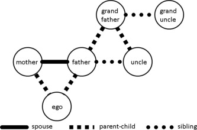

1. [Download : Download full-size image](https://ars.els-cdn.com/content/image/1-s2.0-S0957417412006136-gr2.jpg)

Fig. 2. Construction of the ego centric network

The egocentric network approach has the distinct advantage that its analysis is related to the traditional attribute-based methodology, in that the typical predictors (socio-demographics, purchase history, etc.) are augmented with network measures that are deduced from the ego network (Knoke & Yang, 2007). Moreover, other methods that emerged from social network analysis are only suitable for networks up to a few dozen to a few hundred customers, whereas the egocentric network approach is able to handle the typical CRM datasets with hundreds of thousands of customers (Hill et al., 2006). The egocentric network created in this research, contains all alters no more than two ties removed from ego. The network that emerges from this method is thus a 2nd order egocentric network.

This strategy has various advantages. First, in social network analysis, it is well recognized that individuals who are more than two links away do not exert a significant influence on the focal customer (Knoke & Yang, 2007). Second, since the company database only includes information on immediate family, the 2nd order ego network extends the 1st order ego network with other relevant family, while distant family members are excluded. For example (see Fig. 2), ego can now be influenced by his/her grandfather, but not by his/her granduncle, since the latter is three links away from ego. Finally, the 2nd order egocentric network approach has the additional advantage of increasing data quality. Network data is very labor-intensive to collect and missing information on the ties is likely to occur (Wasserman & Faust, 1994). By using a 2nd order egocentric network, this can be partly overcome. In Fig. 2, when the link between ego and his/her mother is missing in the data warehouse, ego’s mother would not be included in ego’s network. By considering all alters no more than two ties removed from ego, his/her mother will also be included in the ego network and the resulting ego network did not suffer from the missing data.

### 2.2. Social network metrics

At this point we have defined how we can indentify the kinship network of a given customer (i.e. using the 2nd order egocentric network approach). The question, however, still remains what the effects are that play in this network environment and how these effects can be quantified and measured. Earlier work on economic and social theory gives guidance in this respect.

According to Manski (2000) three types of network influence may occur. A first type is endogenous interaction, meaning that the propensity of an agent to behave in some way varies with the behavior of the group. This is the most intuitive network effect and is often central in studies of peer influence. Recently, a number of studies have corroborated the existence of such an effect in different situations. Nair, Manchanda, and Bhatia (2006) found that physicians are influenced by the prescription behavior of their colleagues. In a similar setting, Manchanda et al. (2008) also found evidence for the existence of endogenous interaction. Finally, Hill et al. (2006) showed that cell phone users are more inclined to upgrade their account when they call to people using such an upgraded account. Most often, this effect is represented by a dummy variable that flags one of the behavior of interest is already present in the network of the focal customer.

A second type of network influence is contextual interaction (Manski, 2000). Here, the propensity of an actor to behave in some way varies with the exogenous characteristics of the group members. To clarify this, consider this example: A variable indicating social class is often based on the geographic area where a customer lives. This variable only is an approximation of the customers’ social class and thus can be inaccurate. A variable returning the average social class score of the network members might be more accurate in indicating social class or at least give some additional information about the this customer. The effect on the individual customer of this latter variable is what is called a contextual interaction. Although other methods than averaging for summarizing the attributes of the network members are possible, taking the mean of the attributes of the network members is a standard procedure in the extant literature (Manski, 2000).

Finally, a third type of network influence is network structure effects. Centrality measures are some of the most fundamental and frequently used measures of network structure (Newman, 2003, Newman, 2007). Examples are found in Liu (2011) and Kim, Suh, and Jun (2011). Centrality measures address the question: “Who is the most important or central person in this network”. There are many answers to this question, depending on what we mean by ‘important’, giving rise to many different centrality metrics. Kiss and Bichler (2008) investigated which of the various centrality measures are best able to select influential customers. They found out that degree and betweenness centrality are good describers of the capability of a customer to influence others.

#### 2.2.1. Degree centrality

Probably the simplest of the centrality measures is degree centrality (also called degree). It measures the importance of a node by the number of ties that are connected to a given node (Wasserman & Faust, 1994). Degree centrality is illustrated by network A and network B, shown in Fig. 3. Both networks have *m* = 5 actors. Network A has the property that exactly one actor, *n*<sub>1</sub>, has ties to all *m* – 1 other actors. It is clear that the first actor is the most central. In network B, all actors are, from a structural point of view, interchangeable. This means that all actors have the same centrality index. Degree centrality is often interpreted in terms of the immediate risk of a node for catching whatever is flowing through the network, for example a virus, some information, the risk of churn behavior, etc.

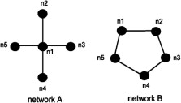

1. [Download : Download full-size image](https://ars.els-cdn.com/content/image/1-s2.0-S0957417412006136-gr3.jpg)

Fig. 3. Degree centrality

Degree centrality can be computed by creating an *m* × *m* matrix where the cells contain a1 value when there is a link between *n<sub>i</sub>* and *n<sub>j</sub>* and a 0 value when no such link exists. The degree, *C<sub>d</sub>*(*n<sub>i</sub>*), of a node *n<sub>i</sub>* is then:(1)$Cd(ni)=∑j=1mxij$Although degree is pretty simple, it is often a highly effective measure of the influence or importance of a node: in many social settings people with more connections tend to have more power (Newman, 2007).

#### 2.2.2. Betweenness centrality

Betweenness is based upon on the concept of network paths. Newman (2007) defines a path in a network as a sequence of nodes traversed by following ties from one to another across the network. A geodesic path is the shortest path through the network from one node to another. Note that there might be (and often is) more than one geodesic path between two nodes (Newman, 2003). The betweenness of a node is calculated as the fraction of shortest paths between node pairs that pass through this node (Freeman, 1979). The betweenness centrality index is defined mathematically by Freeman (1977) as(2)$CB(ni)=∑i≠j≠1gjl(ni)gjl$where *g<sub>ji</sub>*(*n<sub>i</sub>*) is the number of shortest paths linking the two nodes *j* and *l* containing node *i*.

A node with high betweenness will, in many social contexts, exercise most of its influence by virtue not of being in the middle of the network, even though this is possible, but by lying between other nodes in this way (Newman, 2007).

#### 2.2.3. Density

Density is a widely used concept that describes the general level of linkage among the nodes in a network (Scott, 2000). A ‘complete’ network, from density point of view, is a network in which all the nodes are adjacent to another, meaning that each node is connected directly to every other node. The concept of density thus summarizes the overall distribution of ties in terms of how far the state of the network is from a complete network.

Density depends upon two parameters of network structure: First, the inclusiveness of the network and second, the sum of the degrees of its nodes. Inclusiveness stands for the number of nodes that are included within the various connected parts of the network. In other words, the inclusiveness of a network is the total number of nodes minus the number of isolated nodes. An isolated node has no ties so can contribute nothing to the density of the network. Thus, the more inclusive is the graph, the more dense it will be. Those nodes that are connected to one another, however, will vary in their degree of connection. Some nodes will be connected to many other nodes, while others will be less well connected. The higher the degree of the nodes in a network, the denser, it will be.

These two parameters are included in the formula of density. This involves comparing the actual number of ties present in a network with the total number of ties that would be present if the network were incomplete. The density of a network is defined as the number of ties in a network, expressed as a proportion of the maximum possible number of ties. The formula for the density is:(3)$D(ni)=lm(m-1)/2$where *l* is the number of ties present and *m* is the number of nodes in the network.

### 2.4. Evaluation criteria

Many different evaluation criteria are possible for investigating the predictive performance. Evaluation criteria for the predictive performance of classification models are often confusing because of the cut-off value that has to be chosen to discriminate between the predicted events and non-events. The Area Under the Receiver Operating Curve (AUC) avoids this difficulty by considering all possible thresholds on the predicted probabilities. It presents a two-dimensional graph of the sensitivity of the confusion matrix (the number of true positives vs. the total number of defectors) and one minus the specificity of the confusion matrix (the number of true negatives vs. the total number of non-defectors) for all possible cut-offs (Egan, 1975). The area under the resulting curve lies between 0.5 and 1. The closer this value is to 1, the better the model is at discriminating events from non-events. AUC can be interpreted as the probability that the predicted churn probability of a churned customer is higher than the predicted probability of a retained customer. AUC evaluation for predictive accuracy is extensively used in CRM (e.g. Coussement, Benoit, & Van den Poel, 2010; Hill et al., 2006; Lemmens & Croux, 2006) and other data-mining contexts (Takahashi, Takamura, & Okumura, 2009). Comparing the predictive performance of two models using AUC is then conducted using the non-parametric test proposed by DeLong, DeLong, and Clarke-Pearson (1988).

The other performance measure used in this study is “lift”. This evaluation criterion focuses exclusively on the top *x* percent of most critical customers. The top *x* percent riskiest customers (i.e. the group of customers with the highest predicted churn probabilities) represents an ideal segment for targeting in a retention-marketing campaign (Lemmens & Croux, 2006). This performance measure is very attractive because it incorporates somewhat the fact that marketing budgets are limited. As a result, actions to reduce churn (e.g. direct mail campaigns) are limited to a segment of customers that is at high risk. In practice, the metric is calculated by ordering the customers on decreasing predicted churn probability. Next, the proportion of real churners in the top *x* percent is compared with the proportion of churners in the total dataset. The higher the lift, the better is the model. For example, a top-10% lift of 2 means that the model under investigation identifies twice as many churners in the top 10% than a random assignment would do.

AUC and lift are measuring different aspects of the predictive accuracy of the models. Both evaluation criteria provide complementary information. A model can be good at identifying the most risky segment but less effective at recognizing less risky customers. Combining the two metrics provides a thorough evaluation of the performance.

## 3. Results

### 3.1. Data

A European financial services company provided the data for this research project. All active customers at the end of June 2006 were selected, a group of 244,787 clients in total. Information about the customers was extracted from the company data warehouse from the moment they joined the company until June 29th 2006. This information was then captured into explanatory variables (both traditional and social-network-based variables). The dependent variable in this setting is whether a given customer churns or not. Here a churned customer is defined as someone who closed all his/her bank accounts with this company. The dependent variable is based on the churn behavior in the period from June 30th 2006 until December 31st 2006.

Fig. 5 gives a graphical representation of the modeling process. For a given individual all traditional predictors are extracted from the data warehouse. Next, the 2nd order egocentric network is identified for that customer. Using this network, the different network effects that might play are calculated. This is done for every customer in the database and the result is one large table with both traditional as social network based variables for every customer. These predictors then are used as inputs for the random forests and the different types of network effects are evaluated in terms of predictive performance and variable importance.

1. [Download : Download full-size image](https://ars.els-cdn.com/content/image/1-s2.0-S0957417412006136-gr5.jpg)

Fig. 5. Graphical representation of the methodology

Table 1 gives an overview of both traditional and network based-variables used in this study. Traditional churn models usually take socio-demographic variables (age, gender, etc.) as predictors in addition to past behavior that is summarized in terms of recency, frequency and monetary value (RFM). This information is represented in variables 1–12 in Table 1. In the current setting, the traditional churn predictors are augmented with network-based variables. Variables 13–24 contain information on the exogenous characteristics of the network members. Variable 25 accounts for the endogenous network effect, while variables 26–31 capture the network structure influence.

Table 1. Description of variables.

[output not shown]

To avoid overfitting of the model, the database is divided into a training set and a validation set. The model is trained on the training set and tested on the validation set. The training set is composed by randomly assigning 70% of the customers, while the other 30% are assigned to the validation set. In order to get an equal churn rate in both of the sets, stratification is performed on the churn variable. Note that only a very small percentage, i.e. 2%, of the dataset churns in the six month follow-up period.

### 3.2. Results

In order to provide evidence for the hypothesis of additional predictive performance of social network based variables on top of the traditional variables, two different churn models are built. The first prediction model makes use of traditional variables (hereafter called the ‘traditional model’). The second model (or the ‘extended model’) augments the traditional model with the social network indicators.

#### 3.2.1. Predictive performance

Table 2 provides an overview of the predictive performance of both models in terms of lift (measured at different percentiles) and AUC. All metrics of predictive performance are generated on the validation datasets. Table 2 shows that the extended model always has a considerable higher predictive performance than the corresponding traditional model, irrespective of the performance measure used.

Table 2. Predictive performance.

[output not shown]

The AUC metrics demonstrate that the extended model is better in discriminating churners from non-churners. The difference in AUC between the two models is almost 0.04 and this difference is significant (*p* < 0.001) according to the test of Delong et al. (1988). This means that the model augmented with the social network variables does 4% points better in discriminating customers at risk vs. the others. In a churn context within the financial services industry, where even a small change in churn rate strongly affects profit (see Section 1.2), this is a very encouraging result.

The lift values show that the extended model is better at predicting customers at high risk compared to the traditional model. In a marketing context this aspect of predictive accuracy is highly important. Since managers always have to deal with limited budgets, not all customers at risk can be targeted. Therefore they have to restrict the recovery attempts to the customers having the highest churn risk. For example, the top 5% lift shows that the traditional model identifies 5.85 times as many real churners in the top 5% of highest predicted probabilities than a random assessment would do. The extended model however, is able to identify 6.77 times as many real churners. These results show that taking into account the social network based variables leads to a substantial increase in efficiency of the retention program.

#### 3.2.2. Variable importance

In Table 3, the average normalized importance of each predictor for the random forest method is presented. As an importance value of zero means that there is no predictive power in the variable, the table shows that all variable in the model have an impact on the accuracy of the predictions. The sociodemographic variable age exerts the largest impact, while whether a customer uses home banking has the lowest impact.

Table 3. Importance of variables.

| Variable | Importance |
| --- | --- |
| age | 1048.86 |
| recency | 989.74 |
| N_age | 953.85 |
| lor | 942.94 |
| Social_Class_Score | 900.55 |
| N_recency | 788.40 |
| N_lor | 780.56 |
| N_Social_Class_Score | 776.63 |
| Total_Passiva | 567.65 |
| N_int_pur_time | 559.08 |
| N_Total_Passiva | 524.23 |
| int_pur_time | 517.15 |
| N_Total_Activa | 402.52 |
| N_freq | 392.78 |
| N_nbr_insurances | 332.14 |
| Total_Activa | 326.77 |
| freq | 285.07 |
| N_nbr_cred | 254.05 |
| N_sex_m | 249.01 |
| nbr_cred | 183.16 |
| nbr_insurances | 169.03 |
| Degree_Centrality2 | 159.18 |
| density | 127.73 |
| density_rel | 125.43 |
| sex_m | 121.05 |
| betw_c_rel | 104.36 |
| betw_c | 94.12 |
| Degree_Centrality | 87.24 |
| N_churn_1y | 67.09 |
| mis | 43.26 |
| N_Home_Banking | 42.21 |
| Home_Banking | 23.06 |

The importances show that the most important variables in the model are sociodemographic variables together with the RFM variables (i.e. recency, frequency, monetary value, interpurchase time). This finding corroborates previous research in this context (e.g. Baesens, Viaene, Van den Poel, Vanthienen, & Dedene, 2002; Buckinx & Van den Poel, 2005). Apart from the home banking variables, the least important variables turn out to be the network structure measures. However, still having a considerable impact on predictive performance, they do not contribute to the same extent as the socio-demographics and the RFM variables to the performance of the model. This result does not support the results of Hill et al. (2006) where the network structure variables were among the most impactful variables. An interesting and new result from the table of importances is that the aggregate versions of the sociodemographic, RFM and other behavioral variables, i.e. the contextual network variables, have an important impact in discriminating churners from non-churners. In general it is the case that when a given variable on the individual level exerts a large impact on the dependent variable, the network based counterpart variable turns out also to be important compared to the other variables. Note that this effect cannot be linked to possible multicollinearity between the predictors, as the random forests approach (and the method for computing the importances) is not influenced by this phenomenon (Sandri & Zuccolotto, 2006).

Table 4 compares every individual level variable with the network based counterpart variable, i.e. the contextual network effects. The figures show that for seven out of 12 variables, the network based variable has a higher impact on the churn probability than the individual level variable. This leads to the remarkable insight that for those variables it is more beneficial to have the information of the network members of the customer than knowing the value of the variable of the customer him or herself. E.g. Nbr_insurances measures the number of different insurance services the individual customer owns. N_Nbr_insurance represents the number of insurances of the network members of the individual customer. The figures show that it is almost double as important to know the number of insurances of the network members compared to knowing the number of insurances of the individual customer when predicting the individual customers churn probability. This again shows that network based variables not only are important in predicting customer churn, but often they turn out to be even more impactful than the individual counterpart variables.

Table 4. Comparison of importances of contextual variables.

| Variables compared |  |  | Imp<sub>SNA</sub> vs. Imp<sub>trad</sub> |
| --- | --- | --- | --- |
| N_recency | vs. | recency | 0.7966 |
| N_lor | vs. | lor | 0.8278 |
| N_Social_Class_Score | vs. | Social_Class_Score | 0.8624 |
| N_age | vs. | age | 0.9094 |
| N_Total_Passiva | vs. | Total_Passiva | 0.9235 |
| N_int_pur_time | vs. | int_pur_time | 1.0811 |
| N_Total_Activa | vs. | Total_Activa | 1.2318 |
| N_freq | vs. | freq | 1.3778 |
| N_nbr_cred | vs. | nbr_cred | 1.3870 |
| N_Home_Banking | vs. | Home_Banking | 1.8309 |
| N_nbr_insurances | vs. | nbr_insurances | 1.9649 |
| N_sex_m | vs. | sex_m | 2.0570 |

## 4. Discussion

This study presents the benefits of integrating kinship network based information in churn management. It adds to the small but growing literature that investigates the opportunities of network data emerging from individual consumers. To the best of our knowledge, this is the first study that compares the predictive performance of the different network effects in the same context.

Noteworthy is that the current results are both similar and different compared to the main findings of the study of Hill et al. (2006) which also focused on the predictive potential of social network based variables. Similar in the sense that both studies found that network variables improve predictive performance. Different because the improvement in predictive performance was much larger in the study of Hill et al. (2006) than in the current study. Although both studies investigated the influence of social network based variables, Hill et al. (2006) differs in some key aspects from the current study. First, the type of social network is different: the study of Hill et al. (2006) makes use of telecom data (who calls whom), while the current research deals with kinship network information. Moreover, the former study investigates an up-sell context, while here, the focus is on churn behavior. Finally, the two studies deal with a very different industry setting. The differences in effect sizes do confirm Lessig and Park (1978) and Childers and Rao (1992) in that the degree of reference group influence varies for products, consumed on different occasions (public vs. private) and for reference groups (family vs. peers).

Nonetheless, in highly competitive and saturated markets, such as the financial services industry, customer retention is crucial. Better identification of customers at risk and subsequent actions towards those customers has a substantial impact on profits. Incorporating network information turned out to be a viable strategy to achieve this goal.

## References

**Baesens et al., 2002**

B. Baesens, S. Viaene, D. Van den Poel, J. Vanthienen, G. Dedene**Bayesian neural network learning for repeat purchase modelling in direct marketing**

European Journal of Operational Research, 138 (1) (2002), pp. 191-211

[Article](https://www.sciencedirect.com/science/article/pii/S0377221701001291)[Download PDF](https://www.sciencedirect.com/science/article/pii/S0377221701001291/pdfft?md5=4916e384a10bf72707daaaa74fca86d1&pid=1-s2.0-S0377221701001291-main.pdf)[View Record in Scopus](https://www.scopus.com/inward/record.url?eid=2-s2.0-0036532641&partnerID=10&rel=R3.0.0)Google Scholar

**Bar-Yossef et al., 2008**

Z. Bar-Yossef, I. Guy, R. Lempel, Y.S. Maarek, V. Soroka**Cluster ranking with an application to mining mailbox networks**

Knowledge and Information Systems, 14 (1) (2008), pp. 101-139

[CrossRef](https://doi.org/10.1007/s10115-007-0096-0)[View Record in Scopus](https://www.scopus.com/inward/record.url?eid=2-s2.0-37649002567&partnerID=10&rel=R3.0.0)Google Scholar

**Benoit and Van den Poel, 2009**

D.F. Benoit, D. Van den Poel**Benefits of quantile regression for the analysis of customer lifetime value in a contractual setting: An application in financial services**

Expert Systems with Applications, 36 (7) (2009), pp. 10475-10484

[Article](https://www.sciencedirect.com/science/article/pii/S0957417409000712)[Download PDF](https://www.sciencedirect.com/science/article/pii/S0957417409000712/pdfft?md5=ae6861489544a1613accca89280d9f13&pid=1-s2.0-S0957417409000712-main.pdf)[View Record in Scopus](https://www.scopus.com/inward/record.url?eid=2-s2.0-67349144993&partnerID=10&rel=R3.0.0)Google Scholar

**Breiman, 2001**

L. Breiman**Random forests**

Machine Learning, 45 (1) (2001), pp. 5-32

[CrossRef](https://doi.org/10.1023/A:1010933404324)[View Record in Scopus](https://www.scopus.com/inward/record.url?eid=2-s2.0-0035478854&partnerID=10&rel=R3.0.0)[Google Scholar](https://scholar.google.com/scholar_lookup?title=Random%20forests&publication_year=2001&author=L.%20Breiman)

**Buckinx and Van den Poel, 2005**

W. Buckinx, D. Van den Poel**Customer base analysis: Partial defection of behaviorally loyal clients in a non-contractual FMCG retail setting**

European Journal of Operational Research, 164 (1) (2005), pp. 252-268

[Article](https://www.sciencedirect.com/science/article/pii/S0377221703009184)[Download PDF](https://www.sciencedirect.com/science/article/pii/S0377221703009184/pdfft?md5=e65d95412e53129834dfe66962db1e1b&pid=1-s2.0-S0377221703009184-main.pdf)[View Record in Scopus](https://www.scopus.com/inward/record.url?eid=2-s2.0-10444274107&partnerID=10&rel=R3.0.0)Google Scholar

**Chen et al., 2009**

C. Chen, X.F. Yan, F.D. Zhu, J.W. Han, P.S. Yu**Graph OLAP: A multi-dimensional framework for graph data analysis**

Knowledge and Information Systems, 21 (1) (2009), pp. 41-63

[CrossRef](https://doi.org/10.1007/s10115-009-0228-9)[View Record in Scopus](https://www.scopus.com/inward/record.url?eid=2-s2.0-70349972757&partnerID=10&rel=R3.0.0)Google Scholar

**Childers and Rao, 1992**

T.L. Childers, A.R. Rao**The influence of familial and peer-based reference groups on consumer decision**

Journal of Consumer Research, 19 (2) (1992), pp. 198-211

[CrossRef](https://doi.org/10.1086/209296)Google Scholar

**Colgate and Danaher, 2000**

M.R. Colgate, P.J. Danaher**Implementing a customer relationship strategy: The asymmetric impact of poor versus excellent execution**

Journal of the Academy of Marketing Science, 28 (3) (2000), pp. 375-387

[CrossRef](https://doi.org/10.1177/0092070300283006)[View Record in Scopus](https://www.scopus.com/inward/record.url?eid=2-s2.0-23044520403&partnerID=10&rel=R3.0.0)Google Scholar

**Coussement et al., 2010**

K. Coussement, D.F. Benoit, D. Van den Poel**Improved marketing decision making in a customer churn prediction context using generalized additive models**

Expert Systems with Applications, 37 (3) (2010), pp. 2132-2143

[Article](https://www.sciencedirect.com/science/article/pii/S0957417409007325)[Download PDF](https://www.sciencedirect.com/science/article/pii/S0957417409007325/pdfft?md5=d02376cf7cc8933a89472318c832c1a3&pid=1-s2.0-S0957417409007325-main.pdf)[View Record in Scopus](https://www.scopus.com/inward/record.url?eid=2-s2.0-70449526531&partnerID=10&rel=R3.0.0)Google Scholar

**DeLong et al., 1988**

E.R. DeLong, D.M. DeLong, D.L. Clarke-Pearson**Comparing the areas under two or more correlated receiver operating characteristic curves: A nonparametric approach**

Biometrics, 44 (3) (1988), pp. 837-845

[CrossRef](https://doi.org/10.2307/2531595)[View Record in Scopus](https://www.scopus.com/inward/record.url?eid=2-s2.0-0023710206&partnerID=10&rel=R3.0.0)Google Scholar

**Deng et al., 2004**

Y.P. Deng, H.S. Chen, L. Tao, Q.Y. Sha, J. Chen, C.J. Tsai, *et al.***Joint analysis of two microarray gene-expression data sets to select lung adenocarcinoma marker genes**

BMC Bioinformatics, 5 (81) (2004), pp. 1-12

[View Record in Scopus](https://www.scopus.com/inward/record.url?eid=2-s2.0-77950993135&partnerID=10&rel=R3.0.0)Google Scholar

**Domingos and Richardson, 2001**

Domingos, P., & Richardson, M. (2001). Mining the network value of customers. *International Conference on Knowledge Discovery and Data Mining,* 57–66.

Google Scholar

**Egan, 1975**

J.P. Egan**Signal detection theory and ROC analysis**

Academic Press, New York (1975)

[Google Scholar](https://scholar.google.com/scholar_lookup?title=Signal%20detection%20theory%20and%20ROC%20analysis&publication_year=1975&author=J.P.%20Egan)

**Freeman, 1977**

L.C. Freeman**Set of measures of centrality based on betweenness**

Sociometry, 40 (1) (1977), pp. 35-41

[CrossRef](https://doi.org/10.2307/3033543)[View Record in Scopus](https://www.scopus.com/inward/record.url?eid=2-s2.0-33750163961&partnerID=10&rel=R3.0.0)[Google Scholar](https://scholar.google.com/scholar_lookup?title=Set%20of%20measures%20of%20centrality%20based%20on%20betweenness&publication_year=1977&author=L.C.%20Freeman)

**Freeman, 1979**

L.C. Freeman**Centrality in social networks conceptual clarification**

Social Networks, 1 (1979), pp. 215-239

[Article](https://www.sciencedirect.com/science/article/pii/0378873378900217)[Download PDF](https://www.sciencedirect.com/science/article/pii/0378873378900217/pdf?md5=fd3d39a899bd92fc7aa40f2f9f9489d2&pid=1-s2.0-0378873378900217-main.pdf)[View Record in Scopus](https://www.scopus.com/inward/record.url?eid=2-s2.0-0000963519&partnerID=10&rel=R3.0.0)[Google Scholar](https://scholar.google.com/scholar_lookup?title=Centrality%20in%20social%20networks%20conceptual%20clarification&publication_year=1979&author=L.C.%20Freeman)

**Ganesh et al., 2000**

J. Ganesh, M.J. Arnold, K.E. Reynolds**Understanding the customer base of service providers: An examination of the differences between switchers and stayers**

Journal of Marketing, 64 (3) (2000), pp. 65-87

[CrossRef](https://doi.org/10.1509/jmkg.64.3.65.18028)[View Record in Scopus](https://www.scopus.com/inward/record.url?eid=2-s2.0-0034377224&partnerID=10&rel=R3.0.0)Google Scholar

**Hill et al., 2006**

S. Hill, F. Provost, C. Volinsky**Network-based marketing: identifying likely adopters via consumer networks**

Statistical Science, 21 (2) (2006), pp. 256-276

[CrossRef](https://doi.org/10.1214/088342306000000222)[View Record in Scopus](https://www.scopus.com/inward/record.url?eid=2-s2.0-33748544940&partnerID=10&rel=R3.0.0)Google Scholar

**Hu, 2005**

X.H. Hu**A data mining approach for retailing bank customer attrition analysis**

Applied Intelligence, 22 (1) (2005), pp. 47-60

[CrossRef](https://doi.org/10.1023/B:APIN.0000047383.53680.b6)[View Record in Scopus](https://www.scopus.com/inward/record.url?eid=2-s2.0-9144240542&partnerID=10&rel=R3.0.0)[Google Scholar](https://scholar.google.com/scholar_lookup?title=A%20data%20mining%20approach%20for%20retailing%20bank%20customer%20attrition%20analysis&publication_year=2005&author=X.H.%20Hu)

**Kim et al., 2003**

J. Kim, E. Suh, H. Hwang**A model for evaluating the effectiveness of CRM using the balanced scorecard**

Journal of Interactive Marketing, 17 (2) (2003), pp. 5-19

[Article](https://www.sciencedirect.com/science/article/pii/S1094996803701315)[Download PDF](https://www.sciencedirect.com/science/article/pii/S1094996803701315/pdf?md5=ed51fa663e309c1d524d6d31b4e00db2&pid=1-s2.0-S1094996803701315-main.pdf)[CrossRef](https://doi.org/10.1002/dir.10051)[View Record in Scopus](https://www.scopus.com/inward/record.url?eid=2-s2.0-0347308163&partnerID=10&rel=R3.0.0)Google Scholar

**Kim et al., 2011**

S. Kim, E. Suh, Y. Jun**Building a knowledge brokering system using social network analysis: A case study of the Korean financial industry**

Expert Systems with Applications, 38 (2011), pp. 14649-14663

Google Scholar

**Kiss and Bichler, 2008**

C. Kiss, M. Bichler**Identification of influencers – measuring influence in customer networks**

Decision Support Systems, 46 (1) (2008), pp. 233-253

[Article](https://www.sciencedirect.com/science/article/pii/S0167923608001231)[Download PDF](https://www.sciencedirect.com/science/article/pii/S0167923608001231/pdfft?md5=a3027b738919b2acb0b2b8560e9d99cb&pid=1-s2.0-S0167923608001231-main.pdf)[View Record in Scopus](https://www.scopus.com/inward/record.url?eid=2-s2.0-56049120082&partnerID=10&rel=R3.0.0)[Google Scholar](https://scholar.google.com/scholar?q=Identification%20of%20influencers%20%20measuring%20influence%20in%20customer%20networks)

**Knoke and Yang, 2007**

D. Knoke, S. Yang**Social network analysis**

Sage Publications, Los Angeles (2007)

[Google Scholar](https://scholar.google.com/scholar_lookup?title=Social%20network%20analysis&publication_year=2007&author=D.%20Knoke&author=S.%20Yang)

**Larivière and Van den Poel, 2005**

B. Larivière, D. Van den Poel**Predicting customer retention and profitability by using random forests and regression forests techniques**

Expert Systems with Applications, 29 (2) (2005), pp. 472-484

[Article](https://www.sciencedirect.com/science/article/pii/S0957417405000965)[Download PDF](https://www.sciencedirect.com/science/article/pii/S0957417405000965/pdfft?md5=5a4575facc28d83b8bc53a82ee0c913e&pid=1-s2.0-S0957417405000965-main.pdf)[View Record in Scopus](https://www.scopus.com/inward/record.url?eid=2-s2.0-22144481002&partnerID=10&rel=R3.0.0)Google Scholar

**Lemmens and Croux, 2006**

A. Lemmens, C. Croux**Bagging and boosting classification trees to predict churn**

Journal of Marketing Research, 43 (2) (2006), pp. 276-286

[CrossRef](https://doi.org/10.1509/jmkr.43.2.276)[View Record in Scopus](https://www.scopus.com/inward/record.url?eid=2-s2.0-33744526493&partnerID=10&rel=R3.0.0)[Google Scholar](https://scholar.google.com/scholar_lookup?title=Bagging%20and%20boosting%20classification%20trees%20to%20predict%20churn&publication_year=2006&author=A.%20Lemmens&author=C.%20Croux)

**Lessig and Park, 1978**

V.P. Lessig, C.W. Park**Promotional perspective of reference group influence. Advertising implications**

Journal of Advertising, 7 (2) (1978), pp. 41-47

[CrossRef](https://doi.org/10.1080/00913367.1978.10673220)[Google Scholar](https://scholar.google.com/scholar_lookup?title=Promotional%20perspective%20of%20reference%20group%20influence.%20Advertising%20implications&publication_year=1978&author=V.P.%20Lessig&author=C.W.%20Park)

**Li et al., 2005**

S. Li, B. Sun, R.T. Wilcox**Cross-selling sequentially ordered products: An application to consumer banking services**

Journal of Marketing Research, 42 (2) (2005), pp. 233-239

[CrossRef](https://doi.org/10.1509/jmkr.42.2.233.62288)[View Record in Scopus](https://www.scopus.com/inward/record.url?eid=2-s2.0-18444395594&partnerID=10&rel=R3.0.0)Google Scholar

**Liu, 2011**

C.H. Liu**The effects of innovation alliance on network structure and density of cluster**

Expert Systems with Applications, 38 (2011), pp. 299-305

[Article](https://www.sciencedirect.com/science/article/pii/S0957417410005683)[Download PDF](https://www.sciencedirect.com/science/article/pii/S0957417410005683/pdfft?md5=6c87fc0934bd003722837cb315bbcae7&pid=1-s2.0-S0957417410005683-main.pdf)[View Record in Scopus](https://www.scopus.com/inward/record.url?eid=2-s2.0-77956616483&partnerID=10&rel=R3.0.0)[Google Scholar](https://scholar.google.com/scholar_lookup?title=The%20effects%20of%20innovation%20alliance%20on%20network%20structure%20and%20density%20of%20cluster&publication_year=2011&author=C.H.%20Liu)

**Luo et al., 2004**

Luo, T., Kramer, K., Goldgof, D. B., Hall, L. O., Samson, S., Remsen, A., et al. (2004). Recognizing plankton images from the shadow image particle profiling evaluation recorder. *IEEE Transactions on Systems Man and Cybernetics Part B—Cybernetics, 34*(4), 1753–1762.

Google Scholar

**Manchanda et al., 2008**

P. Manchanda, Y. Xie, N. Youn**The role of targeted communication and contagion in product adoption**

Marketing Science, 27 (6) (2008), pp. 961-976

[CrossRef](https://doi.org/10.1287/mksc.1070.0354)[View Record in Scopus](https://www.scopus.com/inward/record.url?eid=2-s2.0-58149255144&partnerID=10&rel=R3.0.0)Google Scholar

**Manski, 2000**

C.F. Manski**Economic analysis of social interactions**

Journal of Economic Perspectives, 14 (3) (2000), pp. 115-136

[CrossRef](https://doi.org/10.1257/jep.14.3.115)[View Record in Scopus](https://www.scopus.com/inward/record.url?eid=2-s2.0-0001492249&partnerID=10&rel=R3.0.0)[Google Scholar](https://scholar.google.com/scholar_lookup?title=Economic%20analysis%20of%20social%20interactions&publication_year=2000&author=C.F.%20Manski)

**Mutanen et al., 2006**

Mutanen T., Ahola, J., & Nousiainen S. (2006). Customer churn prediction – a case study in retail banking. In *ECML/PKDD 2006 workshop on practical data mining: Applications, experiences and challenges*, Berlin.

Google Scholar

**Nair et al., 2006**

Nair, H. S., Manchanda, P., & Bhatia, T. (2006). *Asymmetric social interactions in physician prescription behavior: The role of opinion leaders.* Stanford University, Graduate School of business.

Google Scholar

**Newman, 2003**

M.E.J. Newman**The structure and function of complex networks**

Siam Review, 45 (2) (2003), pp. 167-256

[CrossRef](https://doi.org/10.1137/S003614450342480)[View Record in Scopus](https://www.scopus.com/inward/record.url?eid=2-s2.0-0038718854&partnerID=10&rel=R3.0.0)[Google Scholar](https://scholar.google.com/scholar_lookup?title=The%20structure%20and%20function%20of%20complex%20networks&publication_year=2003&author=M.E.J.%20Newman)

**Newman, 2007**

Newman, M. E. J. (2007). The mathematics of networks. Working Paper: Center for the Study of Complex Systems, University of Michigan, Ann Arbor.

Google Scholar

**Peppard, 2000**

J. Peppard**Customer Relationship Management (CRM) in financial services**

European Management Journal, 18 (3) (2000), pp. 312-327

[Article](https://www.sciencedirect.com/science/article/pii/S026323730000013X)[Download PDF](https://www.sciencedirect.com/science/article/pii/S026323730000013X/pdfft?md5=8efd9013d0f311d808cd65490fb6be72&pid=1-s2.0-S026323730000013X-main.pdf)[View Record in Scopus](https://www.scopus.com/inward/record.url?eid=2-s2.0-0001318577&partnerID=10&rel=R3.0.0)[Google Scholar](https://scholar.google.com/scholar?q=Customer%20Relationship%20Management%20%20in%20financial%20services)

**Prinzie and Van den Poel, 2006**

A. Prinzie, D. Van den Poel**Investigating purchasing patterns for financial services using Markov, MTD and MTDg models**

European Journal of Operational Research, 170 (3) (2006), pp. 710-734

[Article](https://www.sciencedirect.com/science/article/pii/S037722170400342X)[Download PDF](https://www.sciencedirect.com/science/article/pii/S037722170400342X/pdfft?md5=db14a9fcc81a9a147bb064bbd4ef8ee2&pid=1-s2.0-S037722170400342X-main.pdf)[View Record in Scopus](https://www.scopus.com/inward/record.url?eid=2-s2.0-27744497441&partnerID=10&rel=R3.0.0)Google Scholar

**Quinlan, 1986**

J.R. Quinlan**Induction of decision trees**

Machine Learning, 1 (1) (1986), pp. 81-106

[CrossRef](https://doi.org/10.1007/BF00116251)[View Record in Scopus](https://www.scopus.com/inward/record.url?eid=2-s2.0-0002453611&partnerID=10&rel=R3.0.0)[Google Scholar](https://scholar.google.com/scholar_lookup?title=Induction%20of%20decision%20trees&publication_year=1986&author=J.R.%20Quinlan)

**Reichheld, 1996**

F.F. Reichheld**Learning from customer defections**

Harvard Business Review, 74 (2) (1996), pp. 56-69

[View Record in Scopus](https://www.scopus.com/inward/record.url?eid=2-s2.0-44249103470&partnerID=10&rel=R3.0.0)[Google Scholar](https://scholar.google.com/scholar_lookup?title=Learning%20from%20customer%20defections&publication_year=1996&author=F.F.%20Reichheld)

**Reichheld and Sasser, 1990**

F.F. Reichheld, W.E. Sasser**Zero defections – quality comes to services**

Harvard Business Review, 68 (5) (1990), pp. 105-111

[View Record in Scopus](https://www.scopus.com/inward/record.url?eid=2-s2.0-0004297386&partnerID=10&rel=R3.0.0)[Google Scholar](https://scholar.google.com/scholar?q=Zero%20defections%20%20quality%20comes%20to%20services)

**Scott, 2000**

Scott, J. (2000). *Social network analysis: a handbook* (2nd ed.). London Thousand Oaks, CA: SAGE Publications.

[Google Scholar](https://scholar.google.com/scholar?q=Scott,%20J.%20.%20Social%20network%20analysis:%20a%20handbook%20.%20London%20Thousand%20Oaks,%20CA:%20SAGE%20Publications.)

**Sandri and Zuccolotto, 2006**

Sandri, M., & Zuccolotto, P. (2006). Variable selection using random forests. In *Data analysis, classification and the forward search*. Berlin, Heidelberg: Springer.

Google Scholar

**Subelj et al., 2011**

L. Subelj, S. Furlan, M. Bajec**An expert system for detecting automobile insurance fraud using social network analysis**

Expert Systems with Applications, 38 (2011), pp. 1039-1052

[Article](https://www.sciencedirect.com/science/article/pii/S0957417410007712)[Download PDF](https://www.sciencedirect.com/science/article/pii/S0957417410007712/pdfft?md5=ffc035b5b657e3cd7b1fc4c24f69e331&pid=1-s2.0-S0957417410007712-main.pdf)[View Record in Scopus](https://www.scopus.com/inward/record.url?eid=2-s2.0-77956610365&partnerID=10&rel=R3.0.0)Google Scholar

**Takahashi et al., 2009**

K. Takahashi, H. Takamura, M. Okumura**Direct estimation of class membership probabilities for multiclass classification using multiple scores**

Knowledge and Information Systems, 10 (2) (2009), pp. 185-210

[CrossRef](https://doi.org/10.1007/s10115-008-0165-z)[View Record in Scopus](https://www.scopus.com/inward/record.url?eid=2-s2.0-67349151069&partnerID=10&rel=R3.0.0)Google Scholar

**Van den Poel and Larivière, 2004**

D. Van den Poel, B. Larivière**Customer attrition analysis for financial services using proportional hazard models**

European Journal of Operational Research, 157 (1) (2004), pp. 196-217

[Article](https://www.sciencedirect.com/science/article/pii/S0377221703000699)[Download PDF](https://www.sciencedirect.com/science/article/pii/S0377221703000699/pdfft?md5=5e69b309c63d6a81e82c930d84c6792e&pid=1-s2.0-S0377221703000699-main.pdf)[View Record in Scopus](https://www.scopus.com/inward/record.url?eid=2-s2.0-1842478892&partnerID=10&rel=R3.0.0)Google Scholar

**Wasserman and Faust, 1994**

S. Wasserman, K. Faust**Social network analysis: Methods and applications**

Cambridge University Press, Cambridge (1994)

[Google Scholar](https://scholar.google.com/scholar_lookup?title=Social%20network%20analysis%3A%20Methods%20and%20applications&publication_year=1994&author=S.%20Wasserman&author=K.%20Faust)

[View Abstract](https://www.sciencedirect.com/science/article/abs/pii/S0957417412006136)

Copyright © 2012 Elsevier Ltd. All rights reserved.

12

Citations

Captures

[View details](https://plu.mx/plum/a/?doi=10.1016/j.eswa.2012.04.016&theme=plum-sciencedirect-theme&hideUsage=true)

View PDF